# Ford GoBike System Data

## by Madawi Alkahtani

## Investigation Overview

In this project I'll investigate the relationship between average bike ride time and this month February in 2019 and investigate the relationship between duration bike ride time and user type.

## Dataset Overview

> Ford GoBike System Data includes information about individual rides made in a bike-sharing system covering the greater San Francisco Bay area.

As we can see from the graph shows that during the working days there are more trips than the weekend. This is also shows that the highest trips would be during Thursday. Moreover, the lowest number of trip would be on Sunday and Saturday.

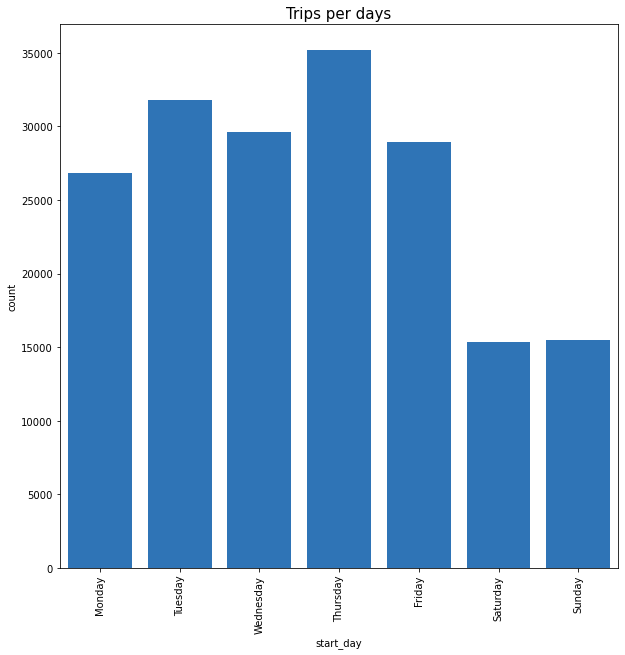

What is the average bike trip by Subscriber and Customer? According to this graph it is clearly that Subscribers have more bike trip than Customers.

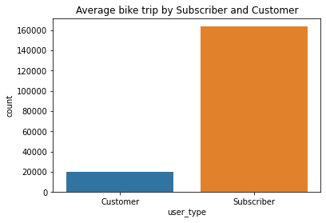

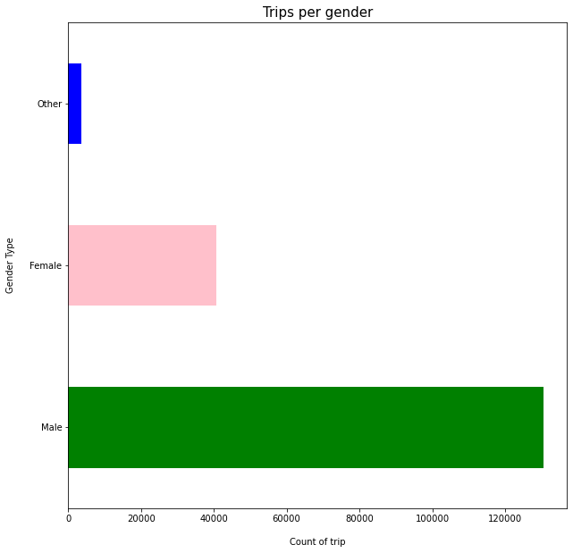

Investigate the relationship between duration bike ride time and user type.

As we can see from the graph above the customer has more duration time than subscriber.

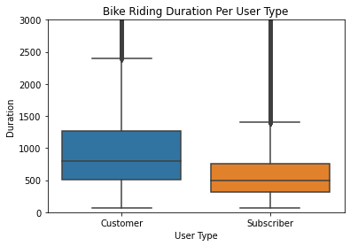

Do subscribers and customers differ in their usage throughout the days of the week?

As ready to see from the charts over the Sunday and Saturday has the greatest contrast in proportion for customers, Where they have a more indeed proportion with the rest of the weekdays when compared to the subscribers, where their ride rate could be a parcel lower when compared to weekdays. My clarification is that subscribers are commuters who for the most part utilize these bicycles for Monday to Friday for work, and by differentiate, will ride them a part less on Sunday and Saturday. customers are more indeed in their utilization all through the week as they do not utilize them for commuting to work but for recreation.

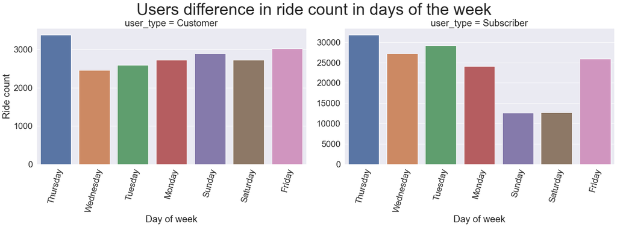

What is the average trip duration variation in weekdays between customers and subscribers ? As we can see from the graph the customer has longest duration trip of subscriber.

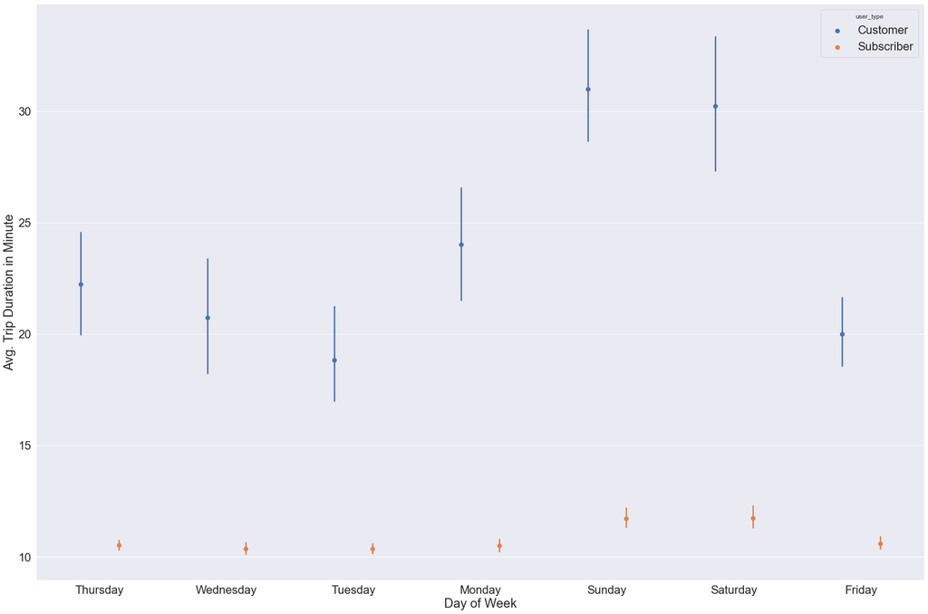

## Summary

### References:

- https://www.kaggle.com/mohamedahmed10000/ford-gobike-system-data-visualization
- https://github.com/az2a/Udacity-Data-Analyst-Nanodegree/blob/main/Ford_go_bike/Ford_go_bikes.ipynb
- https://www.youtube.com/watch?v=JG8GRlMjp3c

[output not shown]

[output cut: 100 more lines]

[output not shown]